# Práctica General

Caros Fernández Escobar

17/1/2022

## Cargar los datos

Cargamos las bibliotecas y los datos de los pingüinos.

```r
library(tidyverse)
library(palmerpenguins)
data <- penguins
```

## Tablas

```r
# Cuento el número de especies y por sexos
data %>% count(species)
```

```
## # A tibble: 3 x 2
##   species       n
##   <fct>     <int>
## 1 Adelie      152
## 2 Chinstrap    68
## 3 Gentoo      124
```

```r
tabla_sexos <- table(data$species,data$sex)
knitr::kable(tabla_sexos,format="markdown")
```

|  | female | male |
| --- | --- | --- |
| Adelie | 73 | 73 |
| Chinstrap | 34 | 34 |
| Gentoo | 58 | 61 |

```r
# Hago un bucle para crear tablas descriptivas para cada variable y luego combinarlas

variables <- c("bill_length_mm","bill_depth_mm","flipper_length_mm","body_mass_g")
list_summary_tables <- list()
for (i in 1:length(variables)) {
list_summary_tables[[i]] <- data %>%
  summarise(variable=variables[i],
            mean=mean(get(variables[i]),na.rm=T),
            sd=sd(get(variables[i]),na.rm=T),
            min=min(get(variables[i]),na.rm=T),
            max=max(get(variables[i]),na.rm=T))
}
summary_table <- bind_rows(list_summary_tables)
knitr::kable(summary_table,format="markdown")
```

| variable | mean | sd | min | max |
| --- | --- | --- | --- | --- |
| bill_length_mm | 43.92193 | 5.459584 | 32.1 | 59.6 |
| bill_depth_mm | 17.15117 | 1.974793 | 13.1 | 21.5 |
| flipper_length_mm | 200.91520 | 14.061714 | 172.0 | 231.0 |
| body_mass_g | 4201.75439 | 801.954536 | 2700.0 | 6300.0 |

El número de individuos totales es 344, de los cuales 152 son de la especie *Adelie* (73 hembras y 73 machos), 68 son de la especie *Chinstrap* (34 hembras y 34 machos) y 124 son de la especie *Gentoo* (58 hembras y 61 machos).

Las estadísticas descriptivas del tamaño de los pingüinos son:

- **Longitud del pico (mm)**: media=43.92, desviación estándar=5.46, mínimo=32.1, máximo=59.6
- **Profundidad del pico (mm)**: media=17.15, desviación estándar=1.97, mínimo=13.1, máximo=21.5
- **Longitud de la aleta (mm)**: media=200.92, desviación estándar=14.06, mínimo=172, máximo=231
- **Tamaño (g)**: media=4201.75, desviación estándar=801.95, mínimo=2700, máximo=6300

## Gráficos

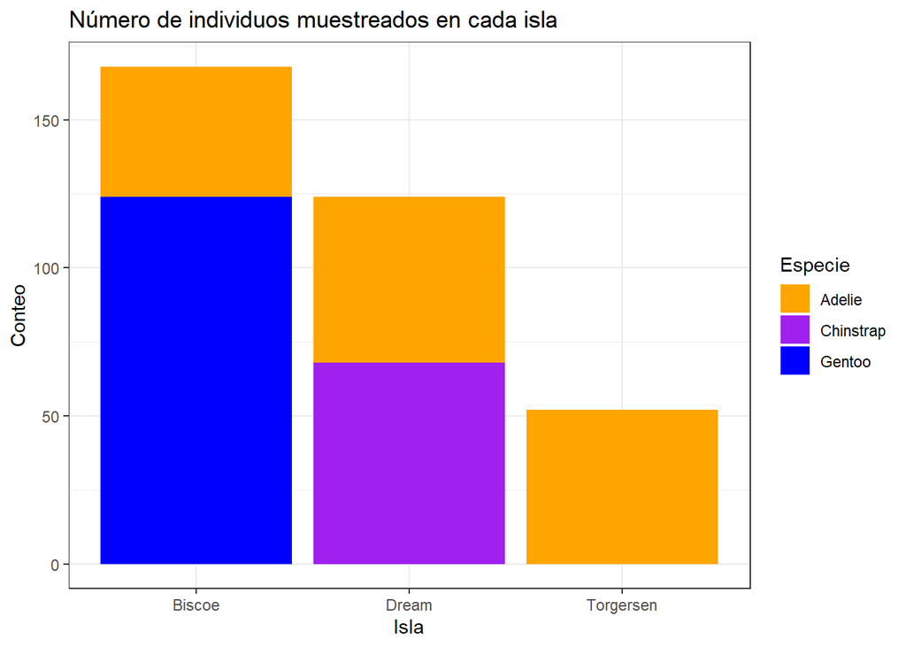

```r
data %>% ggplot(aes(x=island,fill=species)) + geom_bar() +theme_bw()  +labs(y="Conteo", x="Isla", fill="Especie", title="Número de individuos muestreados en cada isla") + scale_fill_manual(values=c("orange","purple","blue"))
```

```r
knitr::kable(addmargins(table(data$species,data$island)),format="markdown")
```

|  | Biscoe | Dream | Torgersen | Sum |
| --- | --- | --- | --- | --- |
| Adelie | 44 | 56 | 52 | 152 |
| Chinstrap | 0 | 68 | 0 | 68 |
| Gentoo | 124 | 0 | 0 | 124 |
| Sum | 168 | 124 | 52 | 344 |

La única especie que se muestreó en las tres islas es *Adelie*. El número total de individuos en la isla Dream fue de 124.

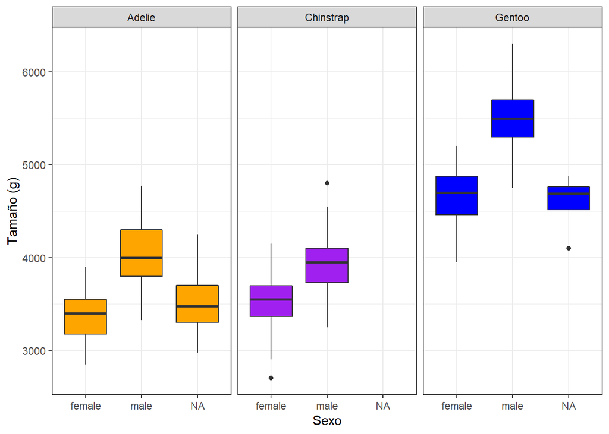

```r
data %>%ggplot(aes(y=body_mass_g,x=sex,fill=species)) + geom_boxplot() + facet_wrap(vars(species)) +theme_bw() + labs(y="Tamaño (g)", x="Sexo") +theme(legend.position = "off") + scale_fill_manual(values=c("orange","purple","blue"))
```

La especie de mayor tamaño fue *Gentoo*. La especie en la que machos y hembras tuvieron un tamaño más similar fue *Chinstrap*.